# Codificación Digital/Analógico 2

## Señal de información

Primero generamos la señal de información y la graficamos:

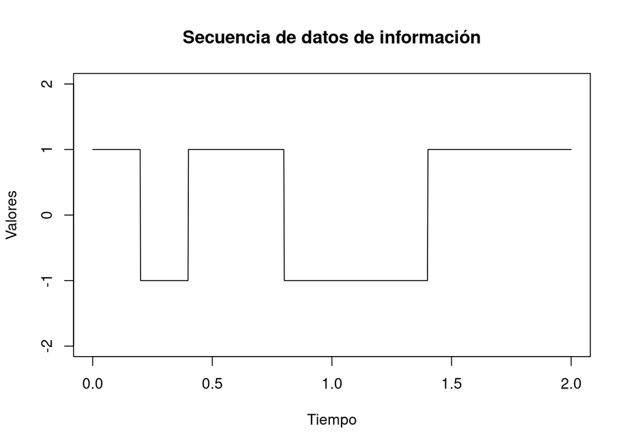

Bits de información. Estos bits serán codifcados por una o más señales analógicas.

```r
# Información original 1-111-1-1-1111
# Representación gráfica
xt <- c(1,-1,1,1,-1,-1,-1,1,1,1)
bits <- rep(xt, each=100)
time <- seq(0,2, length=length(bits))
plot(time, bits, type = "l", main="Secuencia de datos de información", xlab="Tiempo", ylab="Valores", ylim=c(-2,2))
```

Ahora se generan las señales $I(t)$ y $Q(t)$ que se multiplicarán con las señales seno y coseno y ponderadas mediante los valores $\frac{1}{\sqrt{2}}$, en R, éstas señales se generan y se grafican de la siguiente manera:

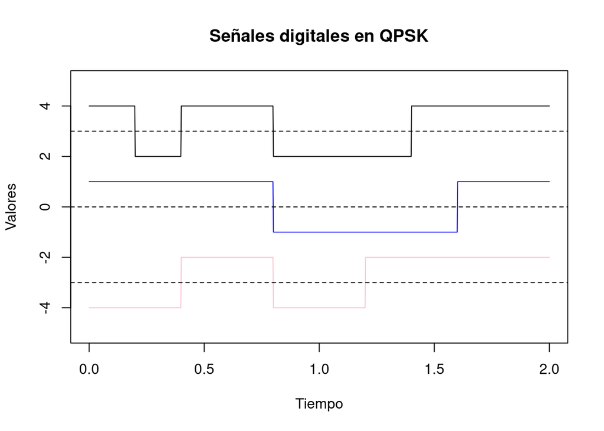

Señal QPSK codifcada mediante la señal de información y las señales $I(t)$ y $Q(t)$

```r
xt       <- c(1,-1,1,1,-1,-1,-1,1,1,1)
bits     <- rep(xt, each=100)
it       <- xt[seq(1, length(xt), by=2)]
qt       <- xt[seq(2, length(xt), by=2)]
itbits   <- rep(it, each=200)
qtbits   <- rep(qt, each=200)
time <- seq(0,2, length=length(bits))
plot(time, bits+3, type = "l", main="Señales digitales en QPSK", xlab="Tiempo", ylab="Valores", ylim=c(-5,5))
lines(time, itbits, col="blue")
lines(time, qtbits-3, col = "pink")
abline(h=3, lty="dashed")
abline(h=-3, lty="dashed")
abline(h=0, lty="dashed")
```

Finalmente, una vez generadas las señales $I(t)$ y $Q(t)$, se genera la señal QPSK de acuerdo a la relación:

$$\mbox{QPSK}: \; \; s(t) = \frac{1}{\sqrt{2}}\left(I(t)\cos(2\pi
ft)-Q(t)\sin(2\pi ft) \right)$$

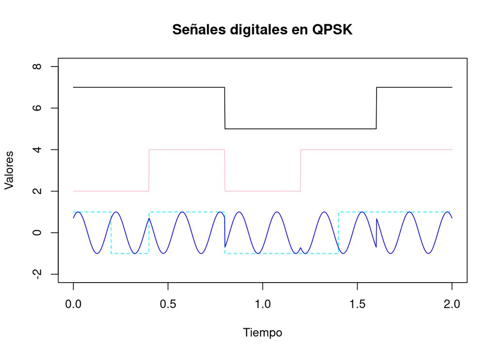

Señal QPSK codificada mediante las señales $I(t)$ y $Q(t)$, las señales seno y coseno

```r
xt       <- c(1,-1,1,1,-1,-1,-1,1,1,1)
bits     <- rep(xt, each=100)
it       <- xt[seq(1, length(xt), by=2)]
qt       <- xt[seq(2, length(xt), by=2)]
itbits   <- rep(it, each=200)
qtbits   <- rep(qt, each=200)
time     <- seq(0,2, length=length(bits))
sen2pi   <- sin(2*pi*5*time)
cos2pi   <- cos(2*pi*5*time)
st       <- 1/sqrt(2)*(itbits*cos2pi - qtbits*sen2pi)
plot(time, itbits+6, type = "l", main="Señales digitales en QPSK", xlab="Tiempo", ylab="Valores", ylim=c(-2,8))
lines(time, qtbits+3, col="pink")
lines(time, bits, col="cyan", lty="dashed")
lines(time, st, col="blue")
```

# Modulación de amplitud en cuadratura

La modulación de amplitud en cuadratura es similar a la modulación QPSK y se puede generar de acuerdo al siguiente diagrama a bloques:

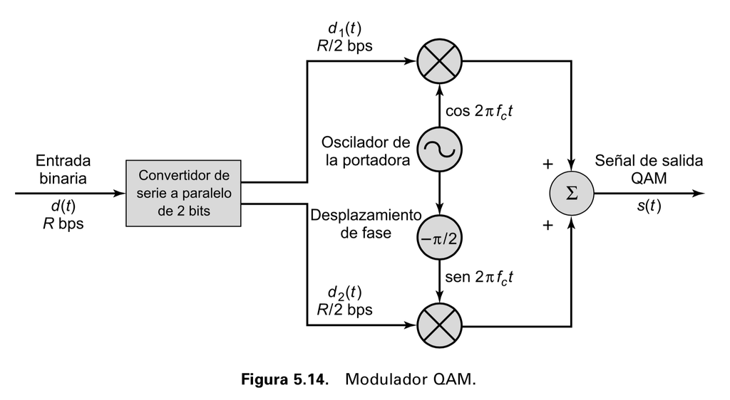

qam

## Tareas

Programar la modulación de amplitud en cuadratura (QAM) siguiendo los mismos pasos que se presentaron para la modulación QPSK. Grafique de la misma manera que se hizo anteriormente.

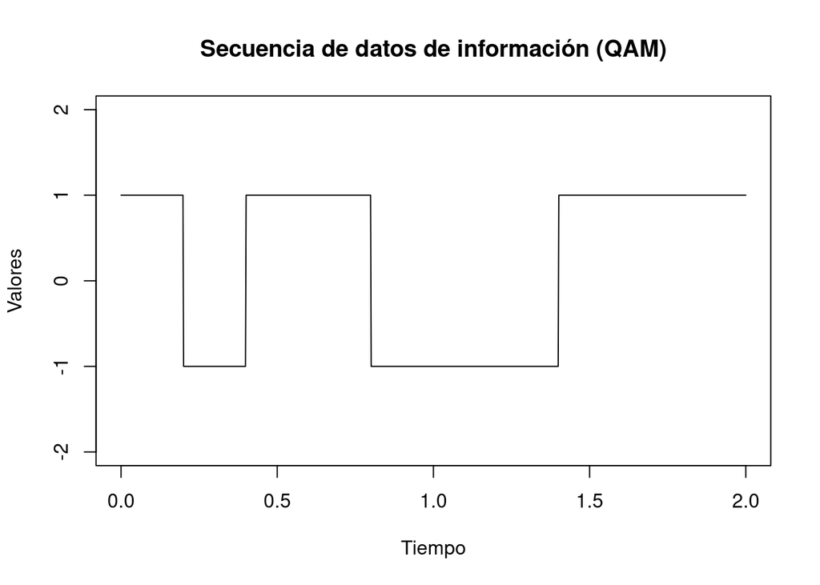

```r
# Información original 1-111-1-1-1111 para la modulación QAM
xt <- c(1,-1,1,1,-1,-1,-1,1,1,1)
bits <- rep(xt, each=100)
time <- seq(0, 2, length=length(bits))

# Gráfica de la secuencia de bits de información
plot(time, bits, type = "l", main="Secuencia de datos de información (QAM)",
     xlab="Tiempo", ylab="Valores", ylim=c(-2, 2))
```

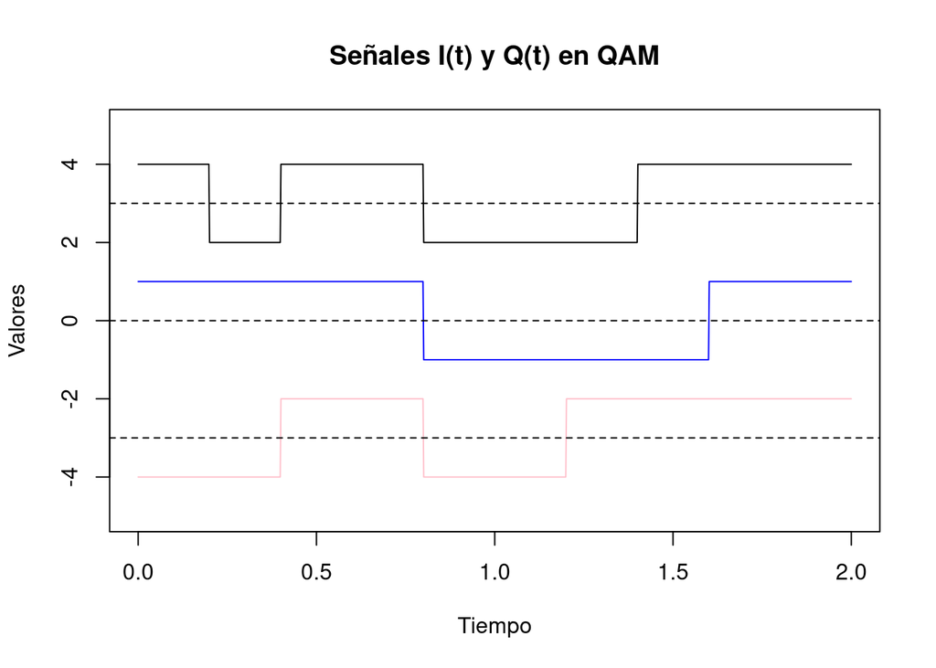

```r
# Generar señales I(t) y Q(t)
it <- xt[seq(1, length(xt), by=2)]
qt <- xt[seq(2, length(xt), by=2)]
itbits <- rep(it, each=200)
qtbits <- rep(qt, each=200)

# Gráfica de las señales I(t) y Q(t)
plot(time, bits + 3, type = "l", main="Señales I(t) y Q(t) en QAM",
     xlab="Tiempo", ylab="Valores", ylim=c(-5, 5))
lines(time, itbits, col="blue")
lines(time, qtbits - 3, col = "pink")
abline(h=3, lty="dashed")
abline(h=-3, lty="dashed")
abline(h=0, lty="dashed")
```

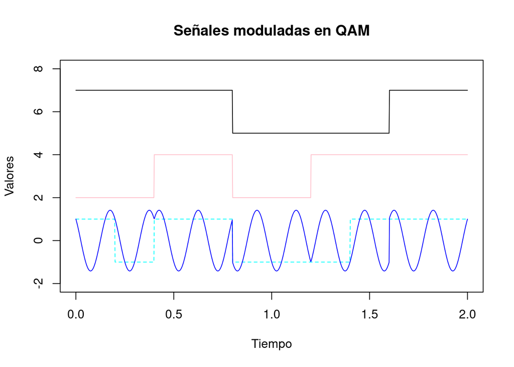

```r
# Generar la señal modulada QAM
sen2pi <- sin(2 * pi * 5 * time)
cos2pi <- cos(2 * pi * 5 * time)
st_qam <- itbits * cos2pi + qtbits * sen2pi

# Gráfica de la señal modulada QAM
plot(time, itbits + 6, type = "l", main="Señales moduladas en QAM",
     xlab="Tiempo", ylab="Valores", ylim=c(-2, 8))
lines(time, qtbits + 3, col="pink")
lines(time, bits, col="cyan", lty="dashed")
lines(time, st_qam, col="blue")
```